# Tutorial for main functions in etsi package

We will go through an example using the main functions in the **etsi** R package. If you are viewing the html version of this tutorial, you can find the R markdown file here: https://github.com/rebeccaknowlton/etsi, it is the file called etsi_tutorial.Rmd. First, install the package from CRAN, and load the package.

```r
# install.packages('etsi')
library(etsi)
```

This package provides functions for treatment effect estimation, hypothesis testing, and future study design for settings where the surrogate is used in place of the primary outcome for individuals for whom the surrogate is valid, and the primary outcome is purposefully measured in the remaining patients. More details are available in: Knowlton R. and Parast L. (2025) ``Efficient Testing Using Surrogate Information (ETSI).” Biometrical Journal, 67(6): e70086.

## Setting

This package is designed for the following setting. There is some prior study that has been conducted, referred to as Study A, and in this study, one has identified that a surrogate marker, $S$, is a strong surrogate marker for a primary outcome $Y$, for a certain subgroup of individuals with certain baseline covariates, $W \in \Omega_W$. The surrogate $S$ is not a strong surrogate for the remaining individuals with $W \in \Omega_W^C$. We now have a subsequent trial, referred to as Study B, where only $S$ has been measured for those with $W \in \Omega_W$ and only $Y$ has been measured for those in $W \in \Omega_W^C$. We wish to test for a treatment effect in Study B combining $S$ and $Y$ measurements, borrowing information about the surrogacy of $S$ from Study A.

The package contains example data for illustration, called **exampledataA** and **exampledataB** which represent Study A and Study B, respectively. Each dataset has the following variables: $A$ which is the randomized treatment indicator with 1 for treatment and 0 for control; $W$, the baseline covariate, $S$, the surrogate marker; $Y$, the primary outcome; delta, an indicator where 1 means $W\in\Omega_W$ and 0 means $W\in\Omega_W^C$. Let’s take a look at these datasets:

```r
data(exampledataA)
data(exampledataB)
exampledataA[1:10, ]
```

```
##    A         W         S          Y delta
## 1  1 2.6550866  5.381964  2.6207717     0
## 2  1 3.7212390  6.075047  2.9266308     0
## 3  1 5.7285336  2.189160  4.0640977     1
## 4  1 9.0820779  3.443186  7.6606940     1
## 5  1 2.0168193  4.350558  0.8810645     0
## 6  1 8.9838968  9.142033 26.9517768     1
## 7  1 9.4467527  2.430692  6.3341126     1
## 8  1 6.6079779  3.886775 10.8541466     1
## 9  1 6.2911404  2.739029  5.6181888     1
## 10 1 0.6178627 10.178557  1.8273040     0
```

```r
exampledataB[1:10, ]
```

```
##    A         W          S          Y delta
## 1  1 0.9870208  4.7297306  1.6159901     0
## 2  1 3.4861731 11.0053834  3.0334723     0
## 3  1 5.3629164  9.7442787 27.9976210     1
## 4  1 0.3377313  6.2983851  0.9134256     0
## 5  1 3.0640316  2.1285872  4.4256961     0
## 6  1 5.8460265 10.7490159 30.9751802     1
## 7  1 2.4269632  5.8519514  3.0747658     0
## 8  1 9.7500804  3.8311923 10.7751862     1
## 9  1 1.9932238  0.8605327  3.1681882     0
## 10 1 4.9581032  5.2183056  1.6712926     0
```

In practice, Study A has complete data on all variables while Study B has $W,A,$ and delta for every individual, but only has non-missing $Y$ if delta=0 and only has non-missing $S$ if delta=1. In this package, Study B data has $Y$ and $S$ for everyone so that a user can compare to existing estimates that use either $Y$ for everyone (costly) or $S$ for everyone (inappropriate because $S$ is not a valid surrogate for everyone). Below, we revise Study B to reflect what we would see in practice:

```r
exampledataB.actual = exampledataB
exampledataB.actual[exampledataB.actual$delta == 1, ]$Y = NA
exampledataB.actual[exampledataB.actual$delta == 0, ]$S = NA
exampledataB.actual[1:10, ]
```

```
##    A         W         S         Y delta
## 1  1 0.9870208        NA 1.6159901     0
## 2  1 3.4861731        NA 3.0334723     0
## 3  1 5.3629164  9.744279        NA     1
## 4  1 0.3377313        NA 0.9134256     0
## 5  1 3.0640316        NA 4.4256961     0
## 6  1 5.8460265 10.749016        NA     1
## 7  1 2.4269632        NA 3.0747658     0
## 8  1 9.7500804  3.831192        NA     1
## 9  1 1.9932238        NA 3.1681882     0
## 10 1 4.9581032        NA 1.6712926     0
```

Often, delta for Study A and B will be provided externally using the user’s choice of method to examine surrogate heterogeneity. However, below, we illustrate one option for defining delta, after demonstrating the main function.

## Testing the treatment effect

The main function is **etsi.main** which estimates the ETSI treatment effect i.e., the pooled treatment effect quantity in Study B, using the surrogate information learned from Study A, the corresponding estimated standard error, and the p-value for testing the null hypothesis of a treatment effect equal to 0. The arguments are **Study.A** for Study A data, **Study.B** for Study B data, and an optional **kappa** argument which is not needed if each individual already has a delta provided in the data.

```r
etsi.main(Study.A = exampledataA, Study.B = exampledataB.actual)
```

```
## $delta.P
## [1] 2.816047
##
## $se.delta.P
## [1] 0.6996762
##
## $p.value
## [1] 5.702715e-05
```

Now, suppose we did not have delta (removed from the dataset below).

```r
exampledataA.nodelta = exampledataA[, !names(exampledataA) %in%
    "delta"]
exampledataB.nodelta = exampledataB[, !names(exampledataB) %in%
    "delta"]
exampledataA.nodelta[1:10, ]
```

```
##    A         W         S          Y
## 1  1 2.6550866  5.381964  2.6207717
## 2  1 3.7212390  6.075047  2.9266308
## 3  1 5.7285336  2.189160  4.0640977
## 4  1 9.0820779  3.443186  7.6606940
## 5  1 2.0168193  4.350558  0.8810645
## 6  1 8.9838968  9.142033 26.9517768
## 7  1 9.4467527  2.430692  6.3341126
## 8  1 6.6079779  3.886775 10.8541466
## 9  1 6.2911404  2.739029  5.6181888
## 10 1 0.6178627 10.178557  1.8273040
```

```r
exampledataB.nodelta[1:10, ]
```

```
##    A         W          S          Y
## 1  1 0.9870208  4.7297306  1.6159901
## 2  1 3.4861731 11.0053834  3.0334723
## 3  1 5.3629164  9.7442787 27.9976210
## 4  1 0.3377313  6.2983851  0.9134256
## 5  1 3.0640316  2.1285872  4.4256961
## 6  1 5.8460265 10.7490159 30.9751802
## 7  1 2.4269632  5.8519514  3.0747658
## 8  1 9.7500804  3.8311923 10.7751862
## 9  1 1.9932238  0.8605327  3.1681882
## 10 1 4.9581032  5.2183056  1.6712926
```

In this case, the function will examine heterogeneity using the nonparametric proportion of treatment effect explained (PTE) as a function of **W** available in the **hetsurr** package, and will define **delta** as 1 when the PTE of $S$ for a specific $W$ is greater than the provided kappa threshold e.g., kappa = 0.5; and 0 otherwise. This takes some computational time because running the heterogeneity function is time-intensive.

```r
etsi.main(Study.A = exampledataA.nodelta, Study.B = exampledataB.nodelta,
    kappa = 0.5)
```

```
## $delta.P
## [1] 2.816047
##
## $se.delta.P
## [1] 0.6996762
##
## $p.value
## [1] 5.702715e-05
```

The estimated ETSI treatment effect in Study B is 2.82 with standard error 0.700 and the corresponding test rejects the null hypothesis of no treatment effect (p<0.001). Now let’s try a higher kappa threshold such as 0.9, meaning that we only want to replace $Y$ with $S$ for an individual if the PTE is greater than 0.9 for that individual’s $W$ value.

```r
etsi.main(Study.A = exampledataA.nodelta, Study.B = exampledataB.nodelta,
    kappa = 0.9)
```

```
## $delta.P
## [1] 2.971161
##
## $se.delta.P
## [1] 0.7141189
##
## $p.value
## [1] 3.174174e-05
```

The estimated ETSI treatment effect in Study B with this threshold is 2.97 with standard error 0.714 and the corresponding test rejects the null hypothesis of no treatment effect (p<0.001).

## Designing a future study

The second main function of the **etsi** package is **etsi.design** which provides information to design a future Study B given data from Study A. Assuming the ETSI testing procedure will be used in Study B, the function calculates either the estimated power for Study B, or the required sample size in each treatment group to achieve a desired level of power in Study B, depending on the inputs. In the code below, we give Study A data and specify a sample size of 400 for the control group in Study B and 500 for the treatment group in Study B.

```r
set.seed(5)
etsi.design(Study.A = exampledataA, n.b0 = 400, n.b1 = 500)
```

```
## $power
## [1] 0.7813381
```

Because we provided the sample size, the function returns the estimated power which is 0.78. You will notice that a seed is set and that the function takes time to run. This is because generalized cross-validation is used within the procedure; the seed is set to ensure reproducibility. Now we illustrate providing the desired power, such that the function returns the required sample size.

```r
set.seed(5)
etsi.design(Study.A = exampledataA, desired.power = 0.9)
```

```
## $sample.size
## [1] 654.1972
```

The required sample size per group is 655. As is true with the **etsi.main** function, if you do not have delta in your Study A data, that is fine, but you will need to provide an argument for **kappa** so that the function can examine heterogeneity via the PTE and using your defined **kappa**. An example is shown below where we use **kappa=0.5**.

```r
set.seed(5)
etsi.design(Study.A = exampledataA.nodelta, desired.power = 0.9,
    kappa = 0.5)
```

```
## $sample.size
## [1] 654.1972
```

It is possible to use these calculations to inform design decisions for Study B. For example, suppose that we would like to take a look at expected power across a range of potential sample sizes from 200 per group to 800 per group, and we are considering various **kappa** thresholds. We can use the function to calculate the expected power at these various options and visualize the results as shown below.

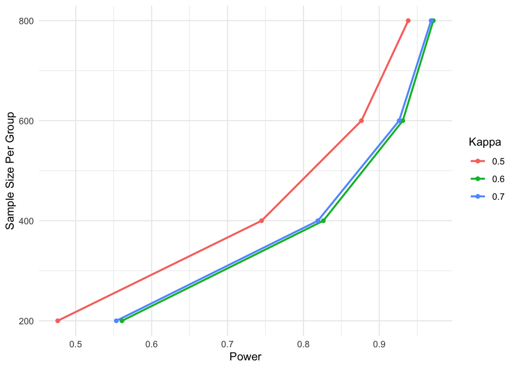

```r
n.vec <- c(200, 400, 600, 800)
kappa.vec <- c(0.5, 0.6, 0.7)
options <- expand.grid(n.vec, kappa.vec)
colnames(options) <- c("n", "kappa")

power.res <- rep(NA, nrow(options))
for (i in 1:nrow(options)) {
    n <- options[i, 1]
    kappa <- options[i, 2]
    set.seed(1)
    power.res[i] <- etsi.design(exampledataA.nodelta, n.b0 = n,
        n.b1 = n, kappa = kappa)$power
}

results.df <- data.frame(sample.size = options[, 1], kappa = options[,
    2], power = power.res)

# plot
library(ggplot2)
# Plot sample size vs power with colors for different kappa
ggplot(results.df, aes(x = power, y = sample.size, color = factor(kappa))) +
    geom_line(size = 0.9) + geom_point() + labs(x = "Power",
    y = "Sample Size Per Group", color = "Kappa") + theme_minimal() +
    theme(legend.position = "right")
```

At this time, this package can only handle a single baseline covariate, W, per observation. That’s all for now!